# Analysis Introduction

## Background on Inpatient Analysis

The intent of this report is to investigate the characterization statement:

> **Characterization Statement 1:** Characterize the individuals being seen for mental health care services (related to depression, bipolar disorder, and suicidality) at least one time – including hospitalization events.

This analyses concerns patients categorized as inpatients. Activating analysis environment:

# Data Analysis Preparation

## Activating Analysis Environment

```julia
using DrWatson
@quickactivate "MentalHealthEquity"
```

## OMOP Table Representation

Using `FunSQL` we will query the table and details about a given schema. In this case, the schema follows the [OMOP CDM v5](https://ohdsi.github.io/CommonDataModel/index.html) schema:

```julia
schema_info = introspect(conn; schema = :synpuf5)
```

> **NOTE** The variable `conn` contains connection details of the form

`conn = LibPQ.Connection("host=myhost port=myport user=myusername _v5 password=mypassword")`.

For this analysis, we will work with the following tables from the schema:

```julia
person = schema_info[:person]
location = schema_info[:location]
observation_period = schema_info[:observation_period]
condition_occurrence = schema_info[:condition_occurrence]
visit_occurrence = schema_info[:visit_occurrence]
care_site = schema_info[:care_site]
```

## Defining Conditions

Bipolar Disorder:

```julia
bipolar_df = CSV.read(
    datadir("exp_raw", "concept_sets", "bipolar_disorder_concept_set.csv"),
    DataFrame,
)
```

Suicidality:

```julia
suicidality_df =
    CSV.read(datadir("exp_raw", "concept_sets", "suicidality_concept_set.csv"), DataFrame)
```

Depression:

```julia
depression_df =
    CSV.read(datadir("exp_raw", "concept_sets", "depression_concept_set.csv"), DataFrame)
```

# Inpatient Cohort

To find the individuals belonging to the inpatient cohort, we utilize the inpatient cohort definition defined with ATLAS (see Cohort Definitions). We load the inpatient codes into the variable `inpatient_codes` using this snippet:

```julia
inpatient_codes = get_atlas_concept_set(
    read(datadir("exp_raw", "queries", "inpatient_cohort.json"), String),
)
```

To get the inpatients in this database, the logical flow is as follows:

1. Select the `visit_occurrence` table
2. Find rows that contain a code from `inpatient_codes` in the `visit_concept_id` column
3. Return all patient IDs from the column `person_id`

Using this logic, the inpatient IDs are saved into the variable `inpatients`. Accordingly, we report 1984582 inpatients in this dataset. Now that all the inpatients have been found, we will characterize them in the following ways:

- Total inpatients by state
- Total inpatients by gender
- Total inpatients by age
- Total inpatients by race
- Total inpatients by care site type

## State Breakdown

To get the inpatient count by state in this database, the logical flow is as follows:

1. Select the `person` table
2. Join the `person` table to the `location` table using the `location_id` as the key to join on
3. Find rows that contain a person ID from the `inpatients` variable in the `person_id` column of this joined table
4. Group table by the `state` column
5. Return the counts of patients per each state using the `state` column

Using this logic, we can visualize patient distribution by state as follows:

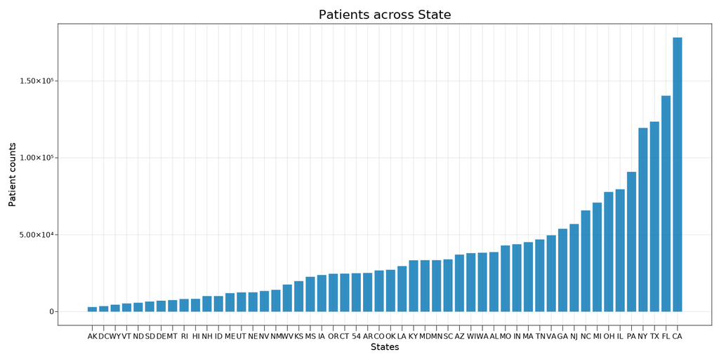

## Age Breakdown

For age breakdowns, inpatient counts were bucketed based on their age. The age brackets were as follows:

1. 0 - 9
2. 10 - 19
3. 20 - 29
4. 30 - 39
5. 40 - 49
6. 50 - 59
7. 60 - 69
8. 70 - 79
9. 80 - 89

To find patient counts per each bucket, the following scheme was used:

1. Select the `person` table
2. Join the `person` table to the `observation_period` table using the `person_id` as the key to join on
3. Find rows that contain a person ID from the `inpatients` variable in the `person_id` column of this joined table
4. Define a new column, `age`, where a patient's age is defined as the last recorded `observation_period_end_date` minus their `year_of_birth`
5. Define a new column, `age_group`, where a patient is given an age group categorization based on the previously stated age breakdown
6. Group resulting table by the `age_group` column
7. Return the counts of patients per age group using the `age_group` column

With this approach, the age group breakdowns and counts can be visualized as follows:

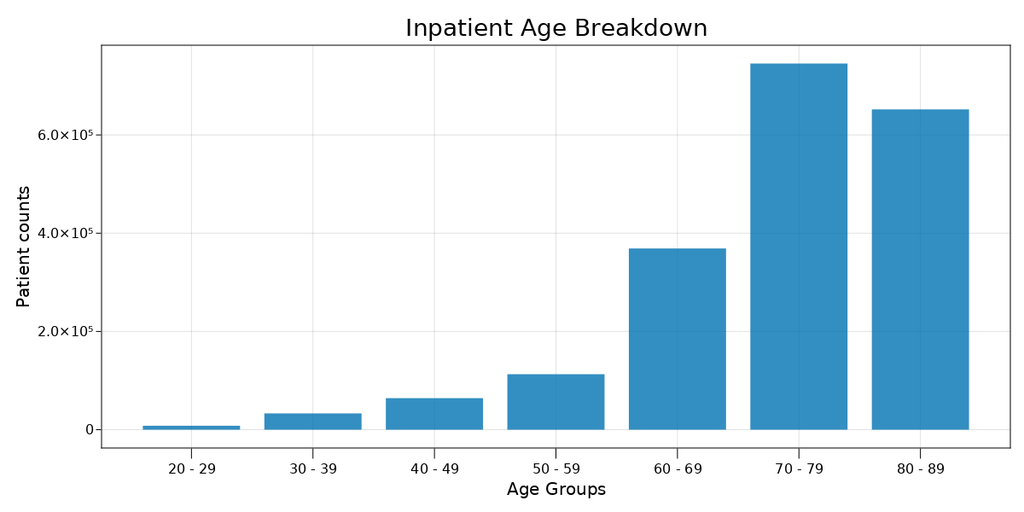

## Racial Breakdown

To get the inpatient counts broken down by race, the logical flow is as follows:

1. Select the `person` table
2. Find rows that contain a person ID from the `inpatients` variable in the `person_id` column
3. Group table by the `race_concept_id` column
4. Return the counts of patients per each recorded race using the `race_concept_id` column

The racial breakdowns can be seen in the following plot:

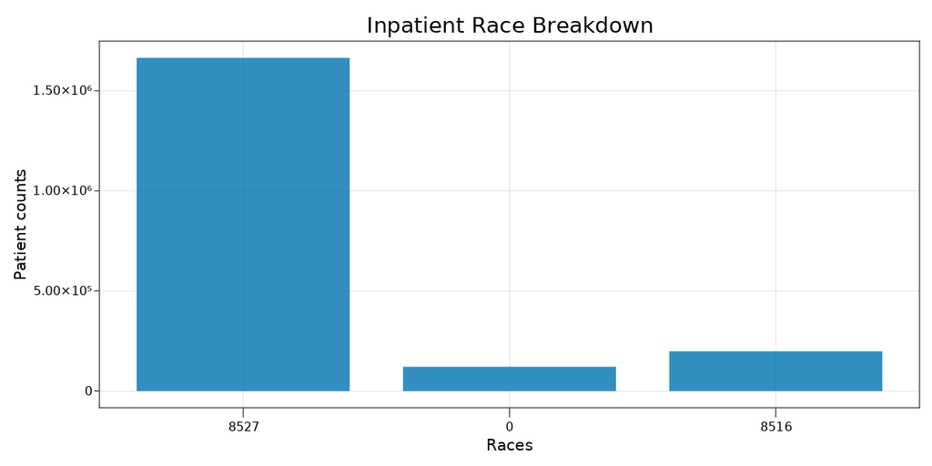

## Gender Breakdown

To get the inpatient counts broken down by gender, the logical flow is as follows:

1. Select the `person` table
2. Find rows that contain a person ID from the `inpatients` variable in the `person_id` column
3. Group table by the `gender_concept_id` column
4. Return the counts of patients per each recorded gender using the `gender_concept_id` column

The gender breakdown can be seen as follows:

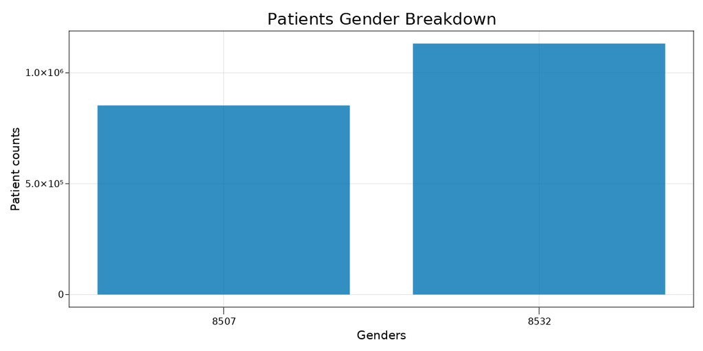

## Care Site Breakdown

To get the patient counts broken down by care site, the logical flow is as follows:

1. Select the `visit_occurrence` table
2. Join the `visit_occurrence` table to the `care_site` table using the `care_site_id` as the key to join on
3. Group table by the `place_of_service_concept_id` column
4. Return the counts of visits per each recorded visit using the `place_of_service_concept_id` column

Here we can visualize the breakdown across `place_of_service_concept_id`:

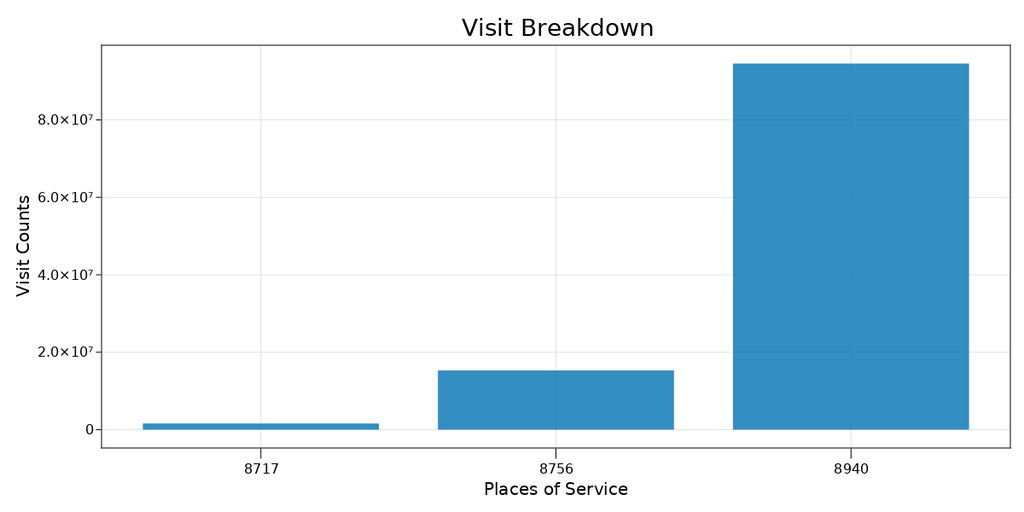

# Characterizing Inpatients with Bipolar Disorder

To calculate all the inpatients with conditions related to bipolar disorder, the logic is as follows:

1. Select the `condition_occurrence` table
2. Find all rows in `condition_occurrence` where `person_id` occurs in the `inpatients` variable
3. Find all rows where `condition_concept_id` occurs in the `CONCEPT_ID` column of the `bipolar_df`
4. Group table by the `person_id` column

## State Breakdown

To get the inpatient count by state in this database, the logical flow is as follows:

1. Select the `person` table
2. Join the `person` table to the `location` table using the `location_id` as the key to join on
3. Find rows that contain a person ID from the `inpatients_bipolar_disorder` variable in the `person_id` column of this joined table
4. Group table by the `state` column
5. Return the counts of patients per each state using the `state` column

Using this logic, we can visualize patient distribution by state as follows:

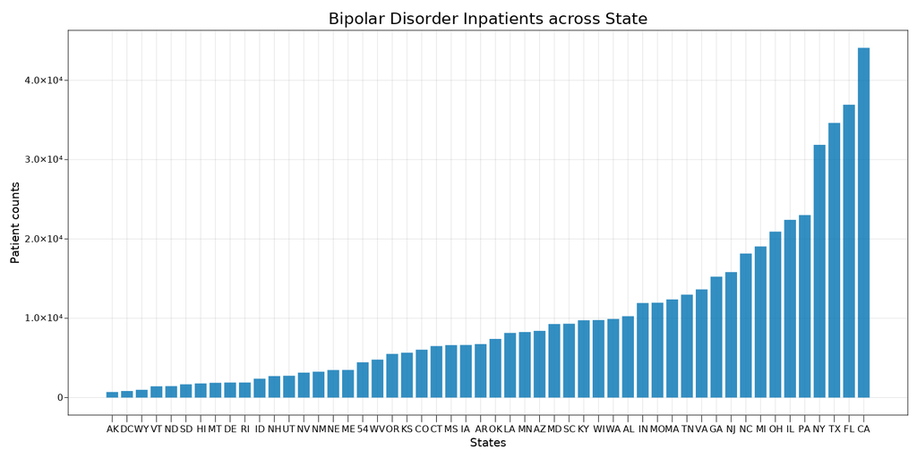

## Age Breakdown

For age breakdowns, inpatient counts were bucketed based on their age. The age brackets were as follows:

1. 0 - 9
2. 10 - 19
3. 20 - 29
4. 30 - 39
5. 40 - 49
6. 50 - 59
7. 60 - 69
8. 70 - 79
9. 80 - 89

To find patient counts per each bucket, the following scheme was used:

1. Select the `person` table
2. Join the `person` table to the `observation_period` table using the `person_id` as the key to join on
3. Find rows that contain a person ID from the `inpatients_bipolar_disorder` variable in the `person_id` column of this joined table
4. Define a new column, `age`, where a patient's age is defined as the last recorded `observation_period_end_date` minus their `year_of_birth`
5. Define a new column, `age_group`, where a patient is given an age group categorization based on the previously stated age breakdown
6. Group resulting table by the `age_group` column
7. Return the counts of patients per age group using the `age_group` column

With this approach, the age group breakdowns and counts can be visualized as follows:

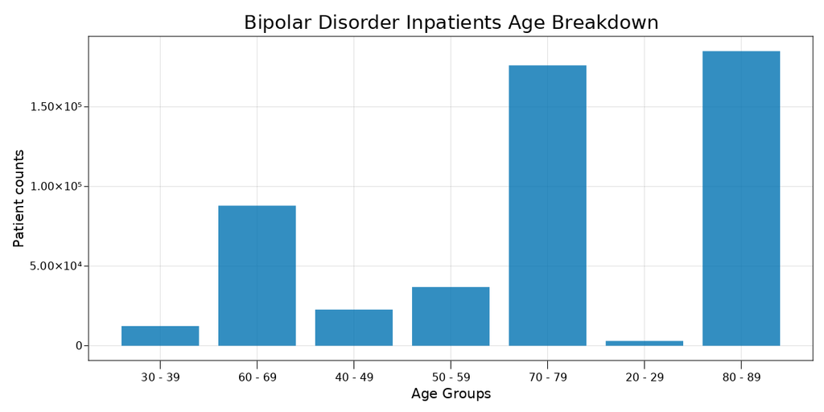

## Racial Breakdown

To get the inpatient counts broken down by race, the logical flow is as follows:

1. Select the `person` table
2. Find rows that contain a person ID from the `inpatients_bipolar_disorder` variable in the `person_id` column
3. Group table by the `race_concept_id` column
4. Return the counts of patients per each recorded race using the `race_concept_id` column

The racial breakdowns can be seen in the following plot:

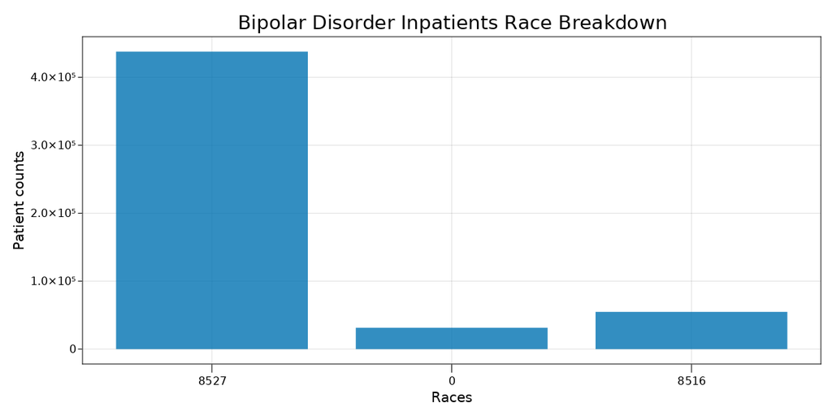

## Gender Breakdown

To get the inpatient counts broken down by gender, the logical flow is as follows:

1. Select the `person` table
2. Find rows that contain a person ID from the `inpatients_bipolar_disorder` variable in the `person_id` column
3. Group table by the `gender_concept_id` column
4. Return the counts of patients per each recorded gender using the `gender_concept_id` column

The gender breakdown can be seen as follows:

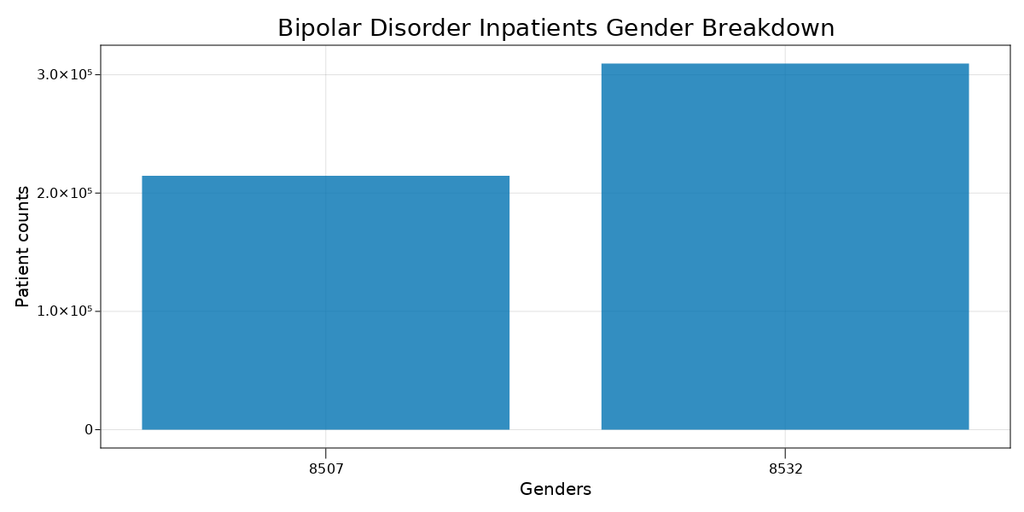

## Care Site Breakdown [TODO]

# Characterizing Inpatients with Depression

1. Select the `condition_occurrence` table
2. Find all rows in `condition_occurrence` where `person_id` occurs in the `inpatients_depression` variable
3. Find all rows where `condition_concept_id` occurs in the `CONCEPT_ID` column of the `depression_df`
4. Group table by the `person_id` column

## State Breakdown

To get the inpatient count by state in this database, the logical flow is as follows:

1. Select the `person` table
2. Join the `person` table to the `location` table using the `location_id` as the key to join on
3. Find rows that contain a person ID from the `inpatients_depression` variable in the `person_id` column of this joined table
4. Group table by the `state` column
5. Return the counts of patients per each state using the `state` column

Using this logic, we can visualize patient distribution by state as follows:

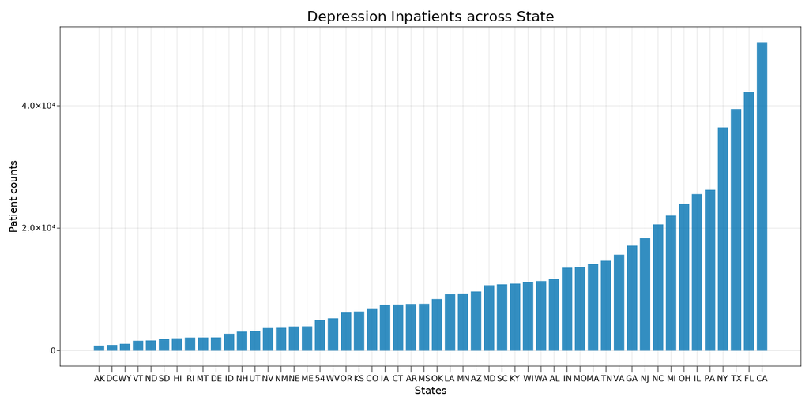

## Age Breakdown

For age breakdowns, inpatient counts were bucketed based on their age. The age brackets were as follows:

1. 0 - 9
2. 10 - 19
3. 20 - 29
4. 30 - 39
5. 40 - 49
6. 50 - 59
7. 60 - 69
8. 70 - 79
9. 80 - 89

To find patient counts per each bucket, the following scheme was used:

1. Select the `person` table
2. Join the `person` table to the `observation_period` table using the `person_id` as the key to join on
3. Find rows that contain a person ID from the `inpatients_depression` variable in the `person_id` column of this joined table
4. Define a new column, `age`, where a patient's age is defined as the last recorded `observation_period_end_date` minus their `year_of_birth`
5. Define a new column, `age_group`, where a patient is given an age group categorization based on the previously stated age breakdown
6. Group resulting table by the `age_group` column
7. Return the counts of patients per age group using the `age_group` column

With this approach, the age group breakdowns and counts can be visualized as follows:

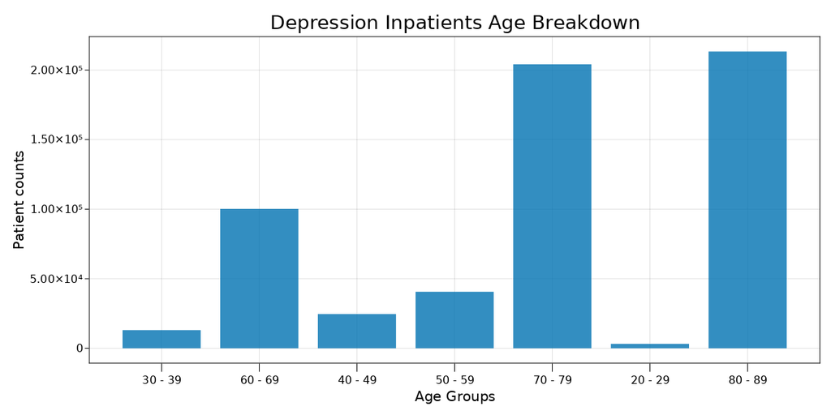

## Racial Breakdown

To get the inpatient counts broken down by race, the logical flow is as follows:

1. Select the `person` table
2. Find rows that contain a person ID from the `inpatients_depression` variable in the `person_id` column
3. Group table by the `race_concept_id` column
4. Return the counts of patients per each recorded race using the `race_concept_id` column

The racial breakdowns can be seen in the following plot:

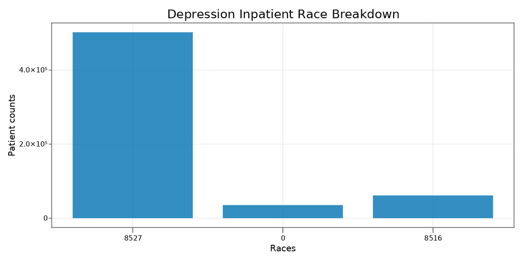

## Gender Breakdown

To get the inpatient counts broken down by gender, the logical flow is as follows:

1. Select the `person` table
2. Find rows that contain a person ID from the `inpatients_depression`
3. Group table by the `gender_concept_id` column
4. Return the counts of patients per each recorded gender using the `gender_concept_id` column

The gender breakdown can be seen as follows:

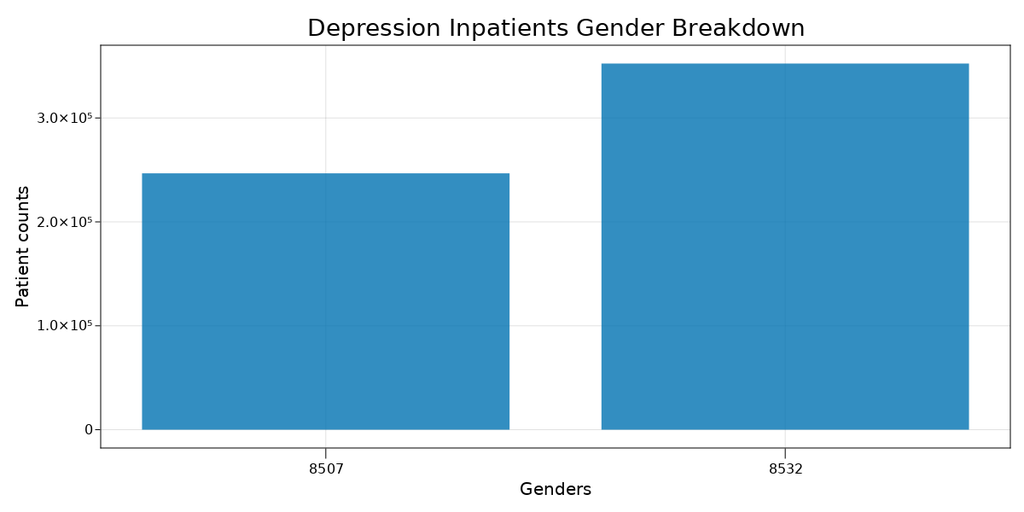

## Care Site Breakdown [TODO]

# Characterizing Inpatients with Suicidality

1. Select the `condition_occurrence` table
2. Find all rows in `condition_occurrence` where `person_id` occurs in the `inpatients_suicidality` variable
3. Find all rows where `condition_concept_id` occurs in the `CONCEPT_ID` column of the `suicidality_df`
4. Group table by the `person_id` column

## State Breakdown

To get the inpatient count by state in this database, the logical flow is as follows:

1. Select the `person` table
2. Join the `person` table to the `location` table using the `location_id` as the key to join on
3. Find rows that contain a person ID from the `inpatients_suicidality` variable in the `person_id` column of this joined table
4. Group table by the `state` column
5. Return the counts of patients per each state using the `state` column

Using this logic, we can visualize patient distribution by state as follows:

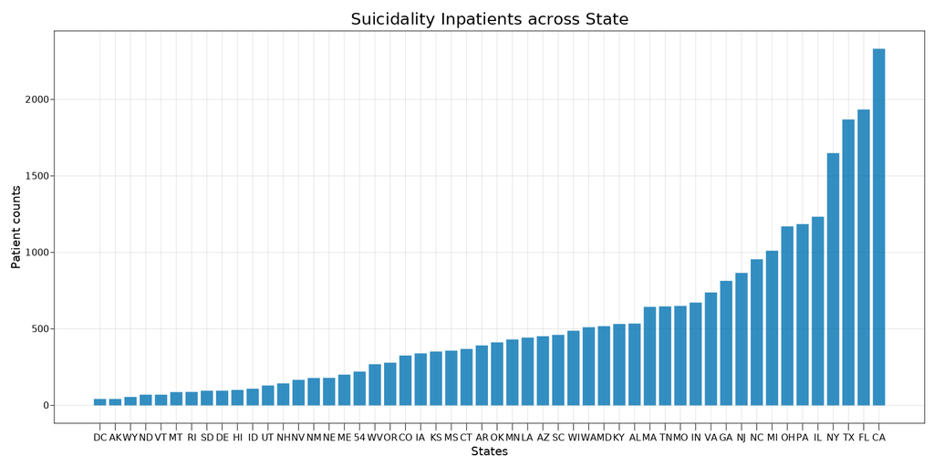

## Age Breakdown

For age breakdowns, inpatient counts were bucketed based on their age. The age brackets were as follows:

1. 0 - 9
2. 10 - 19
3. 20 - 29
4. 30 - 39
5. 40 - 49
6. 50 - 59
7. 60 - 69
8. 70 - 79
9. 80 - 89

To find patient counts per each bucket, the following scheme was used:

1. Select the `person` table
2. Join the `person` table to the `observation_period` table using the `person_id` as the key to join on
3. Find rows that contain a person ID from the `inpatients_suicidality` variable in the `person_id` column of this joined table
4. Define a new column, `age`, where a patient's age is defined as the last recorded `observation_period_end_date` minus their `year_of_birth`
5. Define a new column, `age_group`, where a patient is given an age group categorization based on the previously stated age breakdown
6. Group resulting table by the `age_group` column
7. Return the counts of patients per age group using the `age_group` column

With this approach, the age group breakdowns and counts can be visualized as follows:

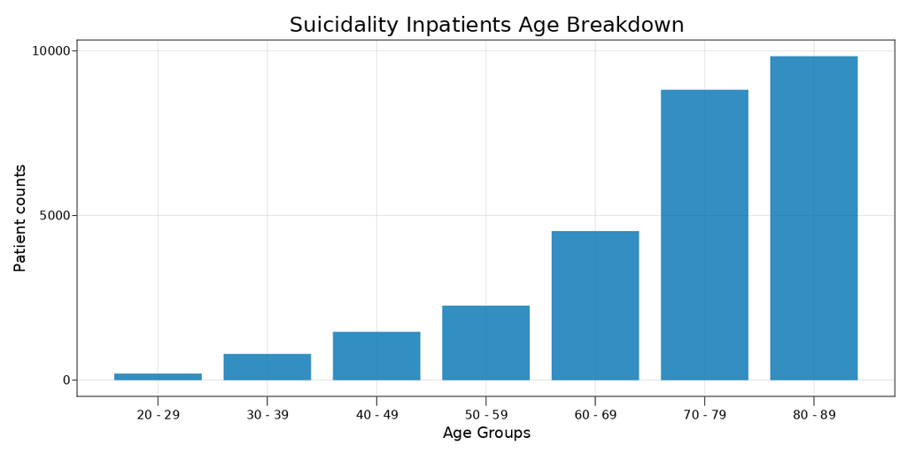

## Racial Breakdown

To get the inpatient counts broken down by race, the logical flow is as follows:

1. Select the `person` table
2. Find rows that contain a person ID from the `inpatients_suicidality` variable in the `person_id` column
3. Group table by the `race_concept_id` column
4. Return the counts of patients per each recorded race using the `race_concept_id` column

The racial breakdowns can be seen in the following plot:

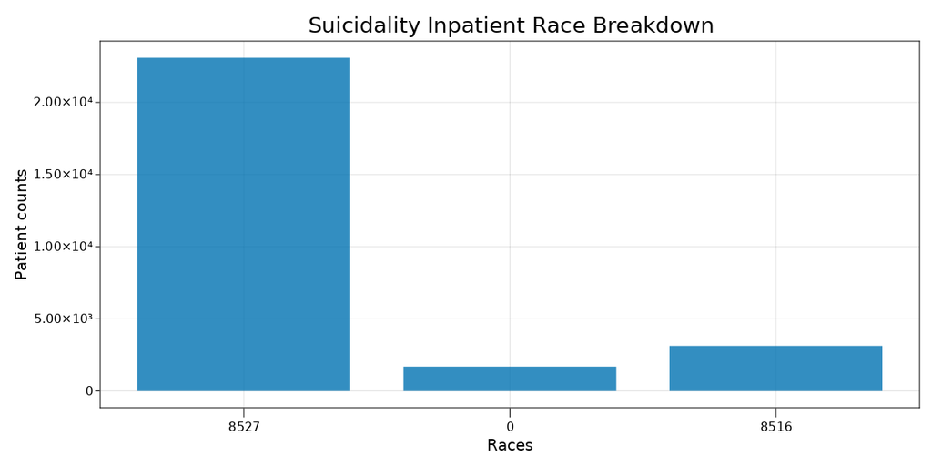

## Gender Breakdown

To get the inpatient counts broken down by gender, the logical flow is as follows:

1. Select the `person` table
2. Find rows that contain a person ID from the `inpatients_suicidality`
3. Group table by the `gender_concept_id` column
4. Return the counts of patients per each recorded gender using the `gender_concept_id` column

The gender breakdown can be seen as follows:

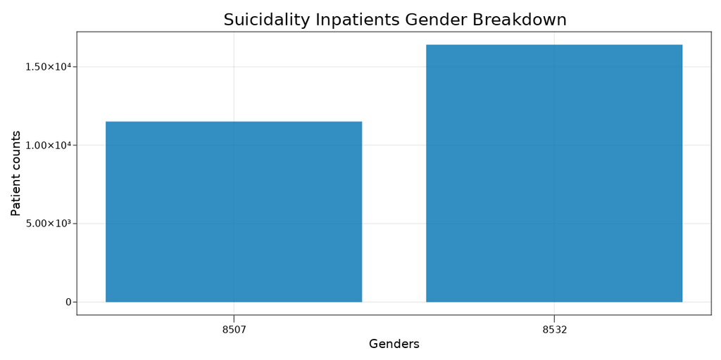

## Care Site Breakdown [TODO]

# Appendix

## Packages Used in Analysis

Package descriptions:

- [`DataFrames`](https://github.com/JuliaData/DataFrames.jl) - Julia's dataframe handler for easily manipulating data
- [`DrWatson`](https://github.com/JuliaDynamics/DrWatson.jl) - Incredibly helpful tool for managing Julia-based scientific experiments and exploration
- [`Makie`](https://github.com/JuliaPlots/Makie.jl) - Data visualization ecosystem for the Julia programming language, with high performance and extensibility
- [`Statistics`](https://github.com/JuliaLang/Statistics.jl) - Julia's standard library for useful statistical methods
- [`Weave`](https://github.com/JunoLab/Weave.jl) - Converts Julia Markdown files to other forms of output

Published from inpatient_cohort.jmd using Weave.jl v0.10.10 on 2021-12-08.